# Formation régionale en analyse démographique pour la décision publique

« Nouvelles sources de données et data science »

Boyam Fabrice Yaméogo, PhD

24 novembre 2026

# Deux Questions :

**Question 1**

Imaginez que vous devez estimer, pour une petite commune de votre pays :

(exemple Grand-Popo, Djibo, Jacqueville, Bubaque, Djenné, Ayorou, Joal-Fadiouth, Aného)

la proportion des enfants de moins de 5 ans qui souffre de malnutrition chronique, et dans quels types de ménages vivent-ils ?

Comment procéderiez-vous ? »

**Question 2**

Le recensement couvre chaque commune ; les enquêtes nationales (EDS, EHCVM) contiennent beaucoup plus d’informations, mais sont seulement représentatives à l’échelle régionale.

Comment pourrait-on selon vous tirer parti des deux types de données à la fois ?

# Plan de présentation

**Les populations synthétiques : comprendre l’essentiel**

1. Qu’est-ce qu’une population synthétique ?
2. L’utilisation de la population synthétique
3. Le problème de départ : « des données en morceaux »
4. Les grandes familles de méthodes
5. Métriques de validation
6. Exemples en Afrique
7. À retenir et questions

# 1. Qu’est-ce qu’une population synthétique ?

# Une définition simple (1/2)

Une **population synthétique** est une **représentation artificielle** mais statistiquement réaliste d’une population réelle (composée d’individus et de ménages fictifs), reconstruite à l’échelle fine d’un territoire en croisant plusieurs sources de données.

Elle est **une représentation microscopique simplifiée de la population réelle** : elle ne reproduit que les variables d’intérêt (Chapuis et Taillandier, 2019)

Nouvelle façon d’exploiter des sources que les INS possèdent déjà : recensement et enquêtes **sans coût de collecte supplémentaire**

# Une définition simple (2/2)

| id | ménage | âge | sexe | milieu | instruction | taille menage |
| --- | --- | --- | --- | --- | --- | --- |
| 1 | M001 | 34 | F | rural | primaire | 3 |
| 2 | M001 | 41 | H | rural | aucun | 3 |
| 3 | M001 | 2 | F | rural | – | 3 |
| 4 | M002 | 27 | F | urbain | secondaire | 1 |

**Propriétés**

- Exhaustivité : autant d’observations que la population réelle
- Microdonnées : chaque ligne est une unité statistique
- Fidélité agrégée : on retrouve les mêmes chiffres / variables agrégées que dans la réalités

# Une image pour comprendre

**La mosaïque**

[figure not shown]

# Une population « à deux niveaux »

Les décisions d’une personne dépendent de ses caractéristiques **et** de celles de son ménage. On cherche donc souvent une population **ménages + individus**.

Une bonne population à deux niveaux doit (Yaméogo et al., 2021) :

1. **garder la structure hiérarchique** : chaque individu appartient à un ménage ;
2. **refléter les différences entre zones** => Une hétérogénité spatiale (communes, régions) ;
3. **reproduire les liens entre membres** d’un même ménage (âge des conjoints, instruction de la mère et des enfants…) ;
4. **respecter les totaux connus** (les « marges »).

# Ce que ce n’est pas

- **Non :** ce n’est pas une vraie population ; on ne peut pas y chercher une personne réelle.
- **Non :** ce n’est pas une projection démographique, même si elle peut en servir de point de départ.
- **Non :** ce n’est pas « inventer des données » au hasard ; tout est **contraint** par des sources officielles.
- **Oui :** c’est un **outil pour combiner des sources** et travailler à un niveau détaillé (individu, ménage, commune).

Une population synthétique peut être vue comme un estimateur :

- qui peut être biaisé si les sources sont incohérentes ou si l’échantillon ne représente pas la zone ;
- avec une variance si la méthode comporte une part alétoire

# 2. L’utilisation de la population synthétique

# Cinq usages principaux

1. **Estimer des indicateurs au niveau local** (commune, village) quand l’enquête n’est représentative qu’au niveau régional.
2. **Alimenter des modèles de simulation** : microsimulation, modèles multi-agents (transport, épidémies, politiques sociales, géographie).
3. **Tester des méthodes d’enquête** sur une « vraie » population connue.
4. **Partager des données sans risque** pour la formation ou la recherche.
5. **Simuler des politiques** : « que se passerait-il si l’on versait un transfert monétaire à tel type de ménage ? »

**Quel indicateur souhaiteriez-vous avoir par commune ?**

# 3. Le problème de départ : « des données en morceaux »

# Deux sources, deux défauts

|  | Recensement (RGPH) | Enquête (EDS) |
| --- | --- | --- |
| Couverture | Tout le monde (+) | Un échantillon (–) |
| Détail géographique | Jusqu’à la commune (+) | Région seulement (–) |
| Nombre de variables | Peu (–) | Beaucoup (+) |
| Forme diffusée | Surtout des tableaux (–) | Des fiches individuelles (+) |

**Pourquoi c’est particulièrement utile en Afrique**

- Les recensements sont espacés (souvent 10 ans ou plus).
- Les EDS sont très riches (fécondité, santé, nutrition, violences…) mais ne portent que sur un **échantillon**.
- Besoin de données détaillées à un niveau spatial fin (plans communaux, ODD, ciblage).
- Certaines zones sont **difficiles d’accès** (insécurité, enclavement).

**Objectif :** obtenir une liste d’individus et de ménages **aussi détaillée que l’EDS** et **aussi complète que le recensement**.

# Le vocabulaire minimal

- **Marges** (totaux de contrôle) : les chiffres connus par le recensement. *Ex. : la commune compte 6 000 femmes rurales et 4 000 femmes urbaines.*
- **Échantillon** (ou « graine ») : les fiches individuelles de l’enquête.
- **Poids de sondage** : combien de personnes réelles « représente » chaque personne enquêtée. *Ex. : une femme de l’EDS peut représenter 800 femmes.*
- **Distribution conjointe** : la façon dont les variables se combinent. *Ex. : combien de femmes sont à la fois rurales ET sans instruction ?*

**Le défi :**

Une enquête (EDS par exemple) couvre en général **bien moins de 5 %** des ménages du pays : ce point comptera pour choisir la méthode.

# 4. Les grandes familles de méthodes

# Vue d’ensemble : trois grandes familles

**1. Reconstruction synthétique (SR)** : repondérer l’échantillon puis **dupliquer**. IPF, IPU, HIPF, calage, maximisation d’entropie.

**2. Optimisation combinatoire (CO)** : **choisir** la meilleure combinaison de ménages pour chaque zone. Recuit simulé, algorithme génétique, *hill-climbing*.

**3. Apprentissage statistique (SL)** : **apprendre** la loi conjointe puis **tirer** de nouveaux individus. MCMC hiérarchique, réseaux bayésiens, mélanges hiérarchiques, IA générative.

**À noter :**

- SR et CO **recopient** des individus existants ; SL **en crée** de nouveaux.
- SR est **déterministe** (mêmes données, même résultat) ; CO et SL sont **aléatoires**.

# La bonne question à se poser d’abord

**De quelles données est-ce que je dispose ?**

| Données disponibles | Famille adaptée |
| --- | --- |
| Un **échantillon** (enquête) **+ des marges** (recensement) | **SR** ou **CO** |
| Un **échantillon** seulement, **sans marges** | **SL** |
| Un **petit échantillon** + des marges | **SL puis SR** (on combine) |
| **Aucun échantillon**, seulement des tableaux | Méthodes **« sans échantillon »** (cas particulier) |

Trois autres questions complètent le choix :

1. Mon échantillon est-il **représentatif et assez grand** ?
2. Combien de **variables** (attributs) veux-je reproduire ?
3. Quelle est la **taille** de la population à générer ?

# L’arbre de décision (Yaméogo et al., 2021)

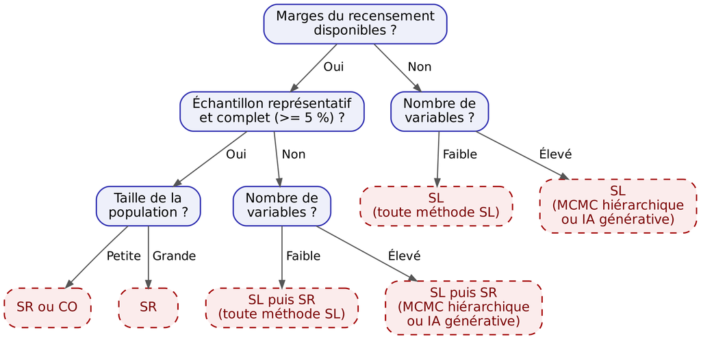

**Avec une EDS + le RGPH** : marges disponibles, mais échantillon bien inférieur à 5 % de la population, donc on s’oriente vers **SL puis SR**.

# Famille 1 : la reconstruction synthétique (SR)

**Idée :** garder les ménages de l’enquête, mais **changer leurs poids** pour que les totaux collent à ceux du recensement de la commune.

*Comme une table de mixage : on monte ou on baisse chaque piste jusqu’à obtenir le bon son.*

**Deux étapes :**

1. **Ajustement** (*fitting*) : calculer un poids pour chaque individu ou ménage de l’échantillon, de sorte que la somme des poids corresponde aux marges. Les poids obtenus ne sont pas entiers.
2. **Allocation** : transformer ces poids en nombres entiers, puis **dupliquer** chaque individu autant de fois que son poids (un poids de 8 donne 8 copies).

C’est la famille **la plus utilisée** : la plupart des logiciels (PopulationSim, PopSynIII, TransCAD…) en font partie.

# SR : l’IPF sur un exemple très simple (1/3)

**Ce que dit l’enquête** (femmes enquêtées, effectifs bruts) :

|  | Non instruite | Instruite | Total |
| --- | --- | --- | --- |
| Rurale | 40 | 10 | 50 |
| Urbaine | 20 | 30 | 50 |

**Ce que dit le recensement pour la commune :**

- 600 rurales et 400 urbaines ;
- 650 non instruites et 350 instruites.

On ne connaît **pas** le croisement dans la commune : on va le **déduire** en respectant la structure de l’enquête.

# SR : l’IPF sur un exemple très simple (2/3)

**Étape 1 : ajuster les lignes** (rural $\times 12$, urbain $\times 8$)

|  | Non instruite | Instruite | Total |
| --- | --- | --- | --- |
| Rurale | 480 | 120 | **600** (atteint) |
| Urbaine | 160 | 240 | **400** (atteint) |
| Total | 640 (non) | 360 (non) |  |

**Étape 2 : ajuster les colonnes** ($\times 650/640$ et $\times 350/360$).

Les colonnes sont alors justes, mais les lignes se décalent un peu : on **recommence**.

# SR : l’IPF sur un exemple très simple (3/3)

**Après quelques allers-retours :**

|  | Non instruite | Instruite | Total |
| --- | --- | --- | --- |
| Rurale | 485 | 115 | 600 |
| Urbaine | 165 | 235 | 400 |
| Total | 650 | 350 |  |

- Les deux marges du recensement sont respectées.
- La tendance de l’enquête est conservée : les urbaines restent plus instruites.

**La seule formule à retenir :**
$$\text{nouvelle valeur} = \text{ancienne valeur} \times \frac{\text{total
visé}}{\text{total actuel}}$$

# SR : passer à deux niveaux (ménages + individus)

L’IPF « classique » ne gère qu’**un seul niveau** : il ne peut pas respecter en même temps les totaux de ménages et les totaux d’individus.

Des méthodes SR **à deux niveaux** calculent un **poids par ménage** qui respecte les deux types de totaux :

- **IPU** : on ajuste d’abord sur les totaux de ménages, puis sur ceux d’individus, et on alterne ;
- **HIPF** (IPF hiérarchique) : on passe sans cesse du « domaine ménages » au « domaine personnes » ;
- **Calage / raking généralisé** : on modifie le moins possible les poids de sondage pour retrouver les totaux connus (méthode bien connue des statisticiens d’enquête) ;
- **Maximisation d’entropie** : on cherche les poids qui ajoutent le moins d’information nouvelle par rapport à l’échantillon.

# SR : avantages et limites

**Avantages**

- Respecte **exactement** les totaux du recensement.
- Conserve la **structure de corrélation** de l’échantillon.
- **Simple, rapide, précise**, et adaptée aux **très grandes populations** (millions de personnes, nombreuses variables).
- Résultat **déterministe** et **largement diffusée** (nombreux logiciels).

**Limites**

- Il faut **à la fois** un échantillon **et** des marges.
- L’échantillon doit être **représentatif et assez grand** (au moins 5 % de la population selon Yaméogo et al., 2021).
- **Problème des cellules vides** (*zero-cell*) : un type d’individu absent de l’échantillon ne sera **jamais** créé. Le risque augmente pour les **petites zones**.
- On **recopie** des individus : peu de diversité.

# Famille 2 : l’optimisation combinatoire (CO)

**Idée :** pour chaque zone, on **pioche** des ménages entiers dans l’échantillon, puis on les **échange** jusqu’à ce que les totaux de la zone soient les plus proches possible.

*Comme composer une équipe : on remplace un joueur tant que l’équipe s’améliore.*

Algorithmes utilisés : **recuit simulé**, algorithme génétique, *hill-climbing*, heuristique gloutonne.

*Références : Williamson, Birkin & Rees (1998) ; Yaméogo et al. (2021).*

# CO : comment ça marche ?

1. **Tirer au hasard** un nombre initial de ménages de l’échantillon pour la zone.
2. **Mesurer l’écart** aux marges de la zone (par ex. somme des Z-scores au carré).
3. **Ajouter, remplacer ou échanger** un ménage ; garder le changement s’il améliore l’ajustement.
4. **Répéter** jusqu’à un seuil de qualité ou un nombre maximal d’itérations.

Chaque zone reçoit ainsi des **ménages entiers**, avec tous leurs membres.

# CO : avantages et limites

**Avantages**

- Produit directement des **ménages entiers** avec leurs individus (deux niveaux naturellement).
- Donne des **effectifs entiers** (pas de « 2,7 personnes »).
- Besoins en données **un peu moins stricts** que pour SR.

**Limites**

- **Très coûteuse en calcul** : quand la population grandit, on n’est plus sûr d’obtenir la meilleure solution. Les applications à deux niveaux restent limitées à de **petites populations** (moins de 60 000 personnes et 30 000 ménages dans les exemples cités par Yaméogo et al., 2021).
- Comme SR : besoin d’un **échantillon + marges**, et **problème des cellules vides**.
- Résultat aléatoire : deux exécutions donnent deux populations différentes.
- **Peu utilisée** en pratique.

# Famille 3 : l’apprentissage statistique (SL)

**Idée :** au lieu de recopier, on **apprend les règles** de la population (sa loi conjointe), puis on **crée** de nouveaux individus qui suivent ces règles.

*Comme un dé fabriqué sur mesure : on apprend ses probabilités, puis on le lance autant de fois que nécessaire.*

**Construction pas à pas :**

1. Je tire le **milieu** (rural/urbain) selon les proportions connues.
2. Sachant le milieu, je tire l’**âge**.
3. Sachant le milieu et l’âge, je tire le **niveau d’instruction**…

$$P(M, A, I) = P(M) \times P(A \mid M) \times P(I \mid M, A)$$
où $M$ = milieu, $A$ = âge, $I$ = instruction.

# SL : les principales méthodes (1/2)

**MCMC hiérarchique (échantillonneur de Gibbs)**

- On tire une variable à la fois, en boucle, jusqu’à stabilité.
- Version à deux niveaux : on génère d’abord le **chef de ménage**, puis le **conjoint**, puis les **enfants**, en tenant compte des membres déjà créés.
- *Farooq et al. (2013) ; Casati et al. (2015)*

**Réseau bayésien**

- Un schéma « qui influence qui » entre variables, puis on tire selon ce schéma.
- *Sun & Erath (2015)*

# SL : les principales méthodes (2/2)

| Méthode | En une phrase |
| --- | --- |
| **Mélange hiérarchique** | Des « classes cachées » de ménages et d’individus capturent les liens entre les deux niveaux. *Sun, Erath & Cai (2018)* |
| **IA générative** (VAE, GAN) | Un réseau de neurones apprend la population et en crée de nouvelles. *Borysov et al. (2019)* |

# SL : le piège des « zéros »

| Type | Exemple | Ce qu’on veut |
| --- | --- | --- |
| **Combinaison rare mais réelle**, absente de l’enquête | Femme rurale de 22 ans, diplômée du supérieur | Pouvoir la **créer** |
| **Combinaison impossible** | Enfant de 3 ans chef de ménage ; fille de 12 ans avec 4 enfants | Ne **jamais** la créer |

- SR et CO ne créent **jamais** la première (cellules vides).
- SL **sait la créer**, mais risque aussi de créer la seconde.

Il faut donc **ajouter des règles de bon sens démographique** (âge du chef de ménage, écart d’âge mère-enfant…).

*Référence : Garrido et al. (2020).*

# SL : avantages et limites

**Avantages**

- Fonctionne avec **un échantillon seul**, même **petit**, et même **sans marges**.
- Crée des individus **absents de l’échantillon** : plus de diversité, pas de problème de cellules vides.
- Combine facilement **plusieurs sources** (échantillons, marges, distributions conditionnelles).

**Limites**

- Ne respecte **pas automatiquement** les totaux du recensement : il faut une **étape de calage** (SR) ensuite.
- Certaines méthodes deviennent **ingérables avec beaucoup de variables** : un réseau bayésien à 6 variables admet environ 3 781 503 de structures possibles, et 1 138 779 265 avec 7 variables.
- Risque de créer des **combinaisons impossibles**.
- Méthodes **récentes**, plus **techniques** (surtout l’IA générative) et **encore peu diffusées**.

# Combiner SL et SR : la chaîne recommandée avec un petit échantillon

1. **SL** : apprendre la population à partir de l’enquête et générer un **grand échantillon synthétique**, riche et diversifié.
2. **SR** : **caler** cet échantillon synthétique sur les totaux du recensement de chaque zone (IPF, calage).
3. **Allocation** : obtenir des effectifs entiers et la population finale.

Borysov et al. au **Danemark** (échantillon de 2,5 % de la population) et Sun et al. à **Singapour** (1 %).

**Pour nos pays (EDS + RGPH), c’est souvent la stratégie la plus adaptée.**

# Un cas particulier : les méthodes « sans échantillon »

Quand **aucune microdonnée** n’est accessible, on peut construire la population **uniquement à partir des tableaux** du recensement :

- on crée des individus à partir des répartitions connues (âge, sexe…) ;
- on les **regroupe en ménages** selon les types de ménages connus.

*Comme une recette : on connaît les ingrédients et les proportions, on assemble les plats.*

- (+) Très peu exigeant en données.
- (–) Les liens entre individus et ménages sont mal reproduits.

*Références : Barthelemy & Toint (2013) ; Lenormand & Deffuant (2013) ; Huynh et al. (2016).*

# Récapitulatif des familles

|  | SR | CO | SL |
| --- | --- | --- | --- |
| Principe | Ajuster puis dupliquer | Combiner des ménages | Apprendre puis tirer |
| Données nécessaires | Échantillon + marges | Échantillon + marges | Échantillon seul |
| Respect des marges | Oui | Oui | Après calage (SR) |
| Taille d’échantillon | Grande | Grande | Petite possible |
| Nombre de variables | Élevé | Élevé | Variable selon la méthode |
| Cellules vides | Oui | Oui | Non |
| Taille de population | Très grande | Petite | Variable |
| Diffusion | Très large | Faible | Faible (récent) |

**Conseil pour débuter :** commencer par **SR** (IPF, calage), puis passer à **SL + SR** quand l’échantillon est petit ou incomplet.

# 5. Métriques de validation

# Valider : à quoi sert-il de mesurer ?

Une population synthétique n’est utile que si elle est **proche de la réalité**. On vérifie trois choses :

1. **L’ajustement aux totaux** : les effectifs simulés collent-ils aux marges du recensement ?
2. **La structure** : les croisements de variables sont-ils réalistes, y compris ceux **non utilisés** pour construire la population ?
3. **L’utilité** : les résultats d’analyse sont-ils les mêmes qu’avec les vraies données ?

**Principe :** on compare, case par case, un tableau **observé** $T_c$ (recensement ou enquête) et le tableau **simulé** $\hat T_c$ correspondant, pour les $C$ cases du tableau.

# Les métriques d’écart les plus utilisées

**Erreur absolue totale (TAE) :** somme des écarts, en nombre de personnes.
$$\text{TAE} = \sum_{c=1}^{C} \left| T_c - \hat T_c \right|$$

**Erreur absolue standardisée (SAE) :** la TAE rapportée à la population totale $N$ ; s’interprète comme un **pourcentage d’erreur**.
$$\text{SAE} = \frac{\text{TAE}}{N}$$

**Erreur quadratique moyenne standardisée (SRMSE) :** pénalise davantage les gros écarts ; 0 = ajustement parfait.
$$\text{SRMSE} = \frac{\sqrt{\frac{1}{C}\sum_{c}(T_c - \hat
T_c)^2}}{\frac{1}{C}\sum_{c} T_c}$$

# Un exemple de calcul

Supposons qu’on connaisse le vrai croisement milieu $\times$ instruction de la commune ($N = 1\,000$) :

| Case | Observé $T_c$ | Simulé $\hat T_c$ | Écart absolu | Écart au carré |
| --- | --- | --- | --- | --- |
| Rurale, non instruite | 480 | 485 | 5 | 25 |
| Rurale, instruite | 120 | 115 | 5 | 25 |
| Urbaine, non instruite | 170 | 165 | 5 | 25 |
| Urbaine, instruite | 230 | 235 | 5 | 25 |

- $\text{TAE} = 20$ personnes ; $\text{SAE} = 20 / 1\,000 = 2\,\%$.
- $\text{SRMSE} = \sqrt{25} / 250 = 5 / 250 = 0{,}02$.

# Autres outils de validation

- **Graphique simulé contre observé** : chaque case est un point ; plus les points sont proches de la diagonale, meilleur est l’ajustement (on peut calculer un $R^2$).
- **Z-scores** par case et leur somme au carré (**RSSZ**), aussi utilisée comme critère d’ajustement en optimisation combinatoire.
- **Pour les méthodes SL :**
  - part des combinaisons générées qui sont **plausibles** (pas de zéros impossibles) ;
  - part des combinaisons réelles que le modèle **retrouve** (diversité).
- **Utilité** : comparer un indicateur (ISF, taux de malnutrition) ou les coefficients d’une régression calculés sur les données synthétiques et sur les vraies données.

**Bonnes pratiques :** générer **plusieurs** populations pour mesurer la variabilité ; valider sur des tableaux **non utilisés** pour la construction ; documenter chaque étape.

# Une question d’éthique

- Recopier des ménages **très atypiques** (très grands, très riches, profession rare) peut permettre de **reconnaître** de vraies personnes, surtout si on les place précisément sur une carte.
- Il faut donc vérifier le **risque de réidentification** avant de diffuser.
- Respecter les **conditions d’utilisation** des données (DHS Program, institut national de la statistique).

# 6. Exemples en Afrique

# Namibie : une population synthétique placée sur la carte

*Thomson, Kools & Jochem (2018)*

- **Pourquoi ?** Vérifier la précision des cartes de population (WorldPop, LandScan) et tester des plans de sondage.
- **Avec quoi ?** Le recensement 2011 (échantillon de 20 %), l’**EDS 2013** et des données géographiques ouvertes.
- **Comment ?** Le package R *simPop* pour créer ménages, femmes et enfants, puis un modèle d’apprentissage automatique (forêts aléatoires) pour **placer chaque ménage sur un bâtiment**.
- **Résultat :** cinq populations synthétiques géolocalisées, cohérentes avec le recensement et l’EDS.

Démarche **directement transposable** à nos pays (RGPH + EDS).

# Afrique du Sud et Kenya : l’IA générative

**Afrique du Sud** (Simmons, Hagan & Schack, 2025)

- Données de l’enquête OMS SAGE (4 227 adultes).
- Comparaison de plusieurs générateurs d’IA (CTGAN, CopulaGAN, TVAE) pour produire des données démographiques et de santé synthétiques réalistes.

**Kenya** (Mwigereri et al., 2025)

- Données d’un site de surveillance démographique et sanitaire (HDSS de Kilifi).
- Un modèle prédictif entraîné sur les données **synthétiques** fonctionne **presque aussi bien** que sur les vraies données.

**Ressource pour la formation :** la Banque mondiale diffuse le recensement synthétique d’un **pays imaginaire** (environ 10 millions d’individus, versions anglaise et française), construit à partir de recensements et d’EDS.

https://datacatalog.worldbank.org/search/dataset/0064618/world-synthetic-data-for-an-imaginary-country-full-population-2023)

# Et chez nous ? Des idées de projets

- **Malnutrition ou vaccination par commune** à partir de l’EDS et du RGPH.
- **Accès aux soins :** croiser la population synthétique localisée avec la carte des centres de santé.
- **Projections par microsimulation :** faire « vieillir » la population (naissances, décès, migrations).
- **Épidémiologie :** simuler la propagation du paludisme ou de la rougeole avec des ménages réalistes.
- **Préparer la prochaine enquête :** tester des plans de sondage sur une population synthétique.

# 7. À retenir et questions

# Messages clés

1. Une population synthétique est une **liste fictive mais réaliste** d’individus et de ménages.
2. Elle sert à **combiner** la couverture du recensement et la richesse des enquêtes.
3. **Le choix de la méthode dépend d’abord des données disponibles** : marges, taille et qualité de l’échantillon, nombre de variables, taille de la population.
4. **SR** respecte les totaux mais recopie ; **CO** est précise mais lente ; **SL** crée de la diversité mais doit être calée et contrôlée.
5. Avec une **EDS + RGPH** : penser **SL puis SR**, en respectant ménages et plan de sondage.
6. Toujours **valider** (TAE, SAE, SRMSE…), générer **plusieurs** versions et **documenter**.

**Prochaine étape : la mise en pratique sous R.**

# Pour aller plus loin (1/2)

**Pour commencer**

- Yaméogo, B. F., Gastineau, P., Hankach, P., & Vandanjon, P.-O. (2021). Comparing methods for generating a two-layered synthetic population. *Transportation Research Record*, 2675(1), 136–147. https://doi.org/10.1177/0361198120964734
- Chapuis, K., Taillandier, P., & Drogoul, A. (2022). Generation of synthetic populations in social simulations: A review of methods and practices. *JASSS*, 25(2), 6. https://doi.org/10.18564/jasss.4762
- Templ, M., Meindl, B., Kowarik, A., & Dupriez, O. (2017). Simulation of synthetic complex data: The R package simPop. *Journal of Statistical Software*, 79(10). https://doi.org/10.18637/jss.v079.i10
- Thomson, D. R., Kools, L., & Jochem, W. C. (2018). Linking synthetic populations to household geolocations: A demonstration in Namibia. *Data*, 3(3), 30. https://doi.org/10.3390/data3030030

**Méthodes classiques (SR, CO)**

- Beckman, R. J., Baggerly, K. A., & McKay, M. D. (1996). *Transportation Research Part A*, 30(6), 415–429. https://doi.org/10.1016/0965-8564(96)00004-3
- Williamson, P., Birkin, M., & Rees, P. H. (1998). *Environment and Planning A*, 30(5), 785–816. https://doi.org/10.1068/a300785
- Lovelace, R., & Ballas, D. (2013). *Computers, Environment and Urban Systems*, 41, 1–11. https://doi.org/10.1016/j.compenvurbsys.2013.03.004
- Lenormand, M., & Deffuant, G. (2013). *JASSS*, 16(4), 12. https://doi.org/10.18564/jasss.2319

# Pour aller plus loin (2/2)

**Apprentissage statistique (SL)**

- Farooq, B., Bierlaire, M., Hurtubia, R., & Flötteröd, G. (2013). *Transportation Research Part B*, 58, 243–263. https://doi.org/10.1016/j.trb.2013.09.012
- Sun, L., & Erath, A. (2015). *Transportation Research Part C*, 61, 49–62. https://doi.org/10.1016/j.trc.2015.10.010
- Sun, L., Erath, A., & Cai, M. (2018). *Transportation Research Part B*, 114, 199–212. https://doi.org/10.1016/j.trb.2018.06.002
- Borysov, S. S., Rich, J., & Pereira, F. C. (2019). *Transportation Research Part C*, 106, 73–97. https://doi.org/10.1016/j.trc.2019.07.006
- Garrido, S., Borysov, S. S., Pereira, F. C., & Rich, J. (2020). *Transportation Research Part C* ; préprint : https://arxiv.org/abs/1909.07689

**Applications africaines**

- Simmons, S. S., Hagan Jr, J. E., & Schack, T. (2025). *Information*, 16(7), 612. https://doi.org/10.3390/info16070612
- Mwigereri, D. G., et al. (2025). *JAMIA Open*, 8(6). https://doi.org/10.1093/jamiaopen/ooaf137

# Merci !

**Questions ?**